# GGGuitar

Casimir Saternos

2016-12-24

This vignettes is a brief introduction to the ggguitar package. The graphics are based on ggplot2 and processing on the tidyverse in general.

```r
library(ggguitar)
library(tibble)
library(ggplot2)

# Ignoring warnings
options( warn = -1 )
```

Special thanks to Dr. Hadley Wickham and the crew at RStudio whose work does all of the heavy lifting.

## Examples of Tablature

A chord in ggguitar is represented as a vector containing 6 elements. Each element represents a string. A numeric value represents the fret where a finger is placed. Zero represents an open string, NA represents a string not played (either skipped or muted).

A G Major chord can be represented using the following vector.

```r
G_M <- c(3, 2, 0, 0, 0, 3)
```

The ggguitar method can be used to create the tablature for this chord. The numbers in the vector represent fret positions with zeros indicating open strings. By default the x and y axis are labeled as Strings and Frets along with associated numbers.

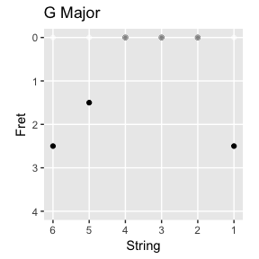

```r
ggguitar::tablature('G Major', G_M)
```

If a given string is not to be played, an NA is used rather than an integer representing the fret number.

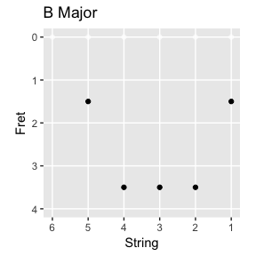

```r
B_M <- c(NA, 2, 4, 4, 4, 2)
ggguitar::tablature('B Major', B_M)
```

Both open strings and ignored/muted strings can be included in the same chord.

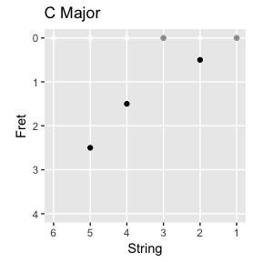

```r
C_M <- c(NA, 3, 2, 0, 1, 0)
ggguitar::tablature('C Major', C_M)
```

Chords need not be restricted to first position. In the next example, a bar chord further up the neck is represented.

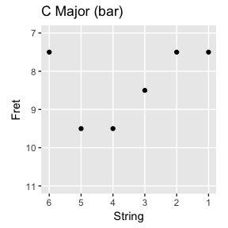

```r
C_M_bar <- c(8, 10, 10, 9, 8, 8)
ggguitar::tablature('C Major (bar)', C_M_bar)
```

## Combining Tablature Images

Charts can be assigned to variables and then displayed together using grid.arrange.

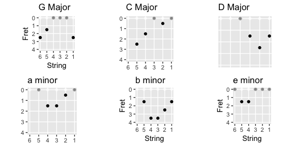

```r
D_M <- c(NA, NA, 0, 2, 3, 2)
F_M7 <- c(NA, NA, 3, 2, 1, 0)
e_m <- c(0, 2, 2, 0, 0, 0)
a_m <- c(NA, 0, 2, 2, 1, 0)
b_m <- c(NA, 2, 4, 4, 3, 2)

G_Major <- tablature('G Major', G_M)
C_Major <- tablature('C Major', C_M, TRUE, FALSE)
D_Major <- tablature('D Major', D_M, FALSE, FALSE)
e_minor <- tablature('e minor', e_m)
a_minor <- tablature('a minor', a_m, TRUE, FALSE)
b_minor <- tablature('b minor', b_m)

gridExtra::grid.arrange(G_Major, C_Major, D_Major,
              a_minor, b_minor, e_minor,
              ncol = 3)
```

## Labeled Frets

In place of dots on frets, labels can be assigned. These can contain finger numbers, scale degrees or any other characters of interest.

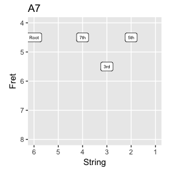

```r
tablature("A7", c(5, NA, 5, 6, 5, NA), dot_labels=c("Root", NA, "7th", "3rd", "5th", NA))
```

The appearance of the labels varies depending on the size of the rendered image. You can assign a size for these labels explicitly.

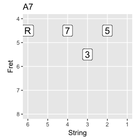

```r
tablature("A7", c(5, NA, 5, 6, 5, NA), dot_labels=c("R", NA, "7", "3", "5", NA), dot_label_size = 5)
```

## Scales

Scales can be presented as well.

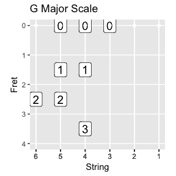

```r
G_M_scale <- c(3, 0,0,0,NA,NA,
               NA,2,2,NA,NA,NA,
               NA,3,4,NA,NA,NA)

tablature('G Major Scale',
           G_M_scale,
           dot_labels=c(2, 0,0,0,NA,NA,
                        NA, 1,1,NA,NA,NA,
                        NA, 2,3,NA,NA,NA),
           dot_label_size = 5)
```

## Chords for Left-handed Guitars

The reverse function - called rev() - in Base-R can be used to render a left-handed version of a chord. If you want the strings on the x-axis, these should be passed using the x_labels parameter.

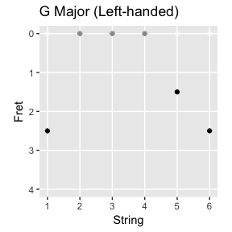

```r
ggguitar::tablature('G Major (Left-handed)',
                    rev(G_M),
                    x_labels = c(1,2,3,4,5,6))
```